# Risk Factor Analysis

## Outcome Variable

**Outcome Variable:** haz

## Predictor Variables

**Intervention Variable:** mhtcm

**Adjustment Set:**

- arm
- W_mage
- meducyrs
- feducyrs
- single
- impsan
- W_gagebrth
- W_birthwt
- W_birthlen
- vagbrth
- parity
- delta_W_mage
- delta_meducyrs
- delta_feducyrs
- delta_single
- delta_impsan
- delta_W_gagebrth
- delta_W_birthwt
- delta_W_birthlen
- delta_vagbrth
- delta_parity

## Stratifying Variables

The analysis was stratified on these variable(s):

- agecat
- studyid
- country

## Data Summary

| agecat | studyid | country | mhtcm | n_cell | n |
| --- | --- | --- | --- | --- | --- |
| 6 months | ki0047075b-MAL-ED | BANGLADESH | >=155 cm | 24 | 241 |
| 6 months | ki0047075b-MAL-ED | BANGLADESH | <151 cm | 156 | 241 |
| 6 months | ki0047075b-MAL-ED | BANGLADESH | [151-155) cm | 61 | 241 |
| 6 months | ki0047075b-MAL-ED | BRAZIL | >=155 cm | 121 | 209 |
| 6 months | ki0047075b-MAL-ED | BRAZIL | <151 cm | 51 | 209 |
| 6 months | ki0047075b-MAL-ED | BRAZIL | [151-155) cm | 37 | 209 |
| 6 months | ki0047075b-MAL-ED | INDIA | >=155 cm | 55 | 235 |
| 6 months | ki0047075b-MAL-ED | INDIA | <151 cm | 112 | 235 |
| 6 months | ki0047075b-MAL-ED | INDIA | [151-155) cm | 68 | 235 |
| 6 months | ki0047075b-MAL-ED | NEPAL | >=155 cm | 41 | 236 |
| 6 months | ki0047075b-MAL-ED | NEPAL | <151 cm | 132 | 236 |
| 6 months | ki0047075b-MAL-ED | NEPAL | [151-155) cm | 63 | 236 |
| 6 months | ki0047075b-MAL-ED | PERU | >=155 cm | 58 | 272 |
| 6 months | ki0047075b-MAL-ED | PERU | <151 cm | 157 | 272 |
| 6 months | ki0047075b-MAL-ED | PERU | [151-155) cm | 57 | 272 |
| 6 months | ki0047075b-MAL-ED | SOUTH AFRICA | >=155 cm | 187 | 249 |
| 6 months | ki0047075b-MAL-ED | SOUTH AFRICA | <151 cm | 31 | 249 |
| 6 months | ki0047075b-MAL-ED | SOUTH AFRICA | [151-155) cm | 31 | 249 |
| 6 months | ki0047075b-MAL-ED | TANZANIA, UNITED REPUBLIC OF | >=155 cm | 147 | 247 |
| 6 months | ki0047075b-MAL-ED | TANZANIA, UNITED REPUBLIC OF | <151 cm | 48 | 247 |
| 6 months | ki0047075b-MAL-ED | TANZANIA, UNITED REPUBLIC OF | [151-155) cm | 52 | 247 |
| 6 months | ki1000304b-SAS-CompFeed | INDIA | >=155 cm | 510 | 1228 |
| 6 months | ki1000304b-SAS-CompFeed | INDIA | <151 cm | 421 | 1228 |
| 6 months | ki1000304b-SAS-CompFeed | INDIA | [151-155) cm | 297 | 1228 |
| 6 months | ki1000304b-SAS-FoodSuppl | INDIA | >=155 cm | 74 | 379 |
| 6 months | ki1000304b-SAS-FoodSuppl | INDIA | <151 cm | 202 | 379 |
| 6 months | ki1000304b-SAS-FoodSuppl | INDIA | [151-155) cm | 103 | 379 |
| 6 months | ki1017093-NIH-Birth | BANGLADESH | >=155 cm | 96 | 537 |
| 6 months | ki1017093-NIH-Birth | BANGLADESH | <151 cm | 311 | 537 |
| 6 months | ki1017093-NIH-Birth | BANGLADESH | [151-155) cm | 130 | 537 |

[output cut: 93 more lines]

The following strata were considered:

- agecat: 24 months, studyid: ki0047075b-MAL-ED, country: BANGLADESH
- agecat: 24 months, studyid: ki0047075b-MAL-ED, country: BRAZIL
- agecat: 24 months, studyid: ki0047075b-MAL-ED, country: INDIA
- agecat: 24 months, studyid: ki0047075b-MAL-ED, country: NEPAL
- agecat: 24 months, studyid: ki0047075b-MAL-ED, country: PERU
- agecat: 24 months, studyid: ki0047075b-MAL-ED, country: SOUTH AFRICA
- agecat: 24 months, studyid: ki0047075b-MAL-ED, country: TANZANIA, UNITED REPUBLIC OF
- agecat: 24 months, studyid: ki1017093-NIH-Birth, country: BANGLADESH
- agecat: 24 months, studyid: ki1017093b-PROVIDE, country: BANGLADESH
- agecat: 24 months, studyid: ki1017093c-NIH-Crypto, country: BANGLADESH
- agecat: 24 months, studyid: ki1066203-TanzaniaChild2, country: TANZANIA, UNITED REPUBLIC OF
- agecat: 24 months, studyid: ki1101329-Keneba, country: GAMBIA
- agecat: 24 months, studyid: ki1119695-PROBIT, country: BELARUS
- agecat: 24 months, studyid: ki1126311-ZVITAMBO, country: ZIMBABWE
- agecat: 24 months, studyid: ki1135781-COHORTS, country: GUATEMALA
- agecat: 24 months, studyid: ki1135781-COHORTS, country: INDIA
- agecat: 24 months, studyid: ki1135781-COHORTS, country: PHILIPPINES
- agecat: 24 months, studyid: ki1148112-LCNI-5, country: MALAWI
- agecat: 24 months, studyid: kiGH5241-JiVitA-3, country: BANGLADESH
- agecat: 6 months, studyid: ki0047075b-MAL-ED, country: BANGLADESH
- agecat: 6 months, studyid: ki0047075b-MAL-ED, country: BRAZIL
- agecat: 6 months, studyid: ki0047075b-MAL-ED, country: INDIA
- agecat: 6 months, studyid: ki0047075b-MAL-ED, country: NEPAL
- agecat: 6 months, studyid: ki0047075b-MAL-ED, country: PERU
- agecat: 6 months, studyid: ki0047075b-MAL-ED, country: SOUTH AFRICA
- agecat: 6 months, studyid: ki0047075b-MAL-ED, country: TANZANIA, UNITED REPUBLIC OF
- agecat: 6 months, studyid: ki1000304b-SAS-CompFeed, country: INDIA
- agecat: 6 months, studyid: ki1000304b-SAS-FoodSuppl, country: INDIA
- agecat: 6 months, studyid: ki1017093-NIH-Birth, country: BANGLADESH
- agecat: 6 months, studyid: ki1017093b-PROVIDE, country: BANGLADESH
- agecat: 6 months, studyid: ki1017093c-NIH-Crypto, country: BANGLADESH
- agecat: 6 months, studyid: ki1066203-TanzaniaChild2, country: TANZANIA, UNITED REPUBLIC OF
- agecat: 6 months, studyid: ki1101329-Keneba, country: GAMBIA
- agecat: 6 months, studyid: ki1112895-Guatemala BSC, country: GUATEMALA
- agecat: 6 months, studyid: ki1119695-PROBIT, country: BELARUS
- agecat: 6 months, studyid: ki1126311-ZVITAMBO, country: ZIMBABWE
- agecat: 6 months, studyid: ki1135781-COHORTS, country: GUATEMALA
- agecat: 6 months, studyid: ki1135781-COHORTS, country: INDIA
- agecat: 6 months, studyid: ki1135781-COHORTS, country: PHILIPPINES
- agecat: 6 months, studyid: ki1148112-LCNI-5, country: MALAWI
- agecat: 6 months, studyid: kiGH5241-JiVitA-3, country: BANGLADESH

### Dropped Strata

Some strata were dropped due to rare outcomes:

- agecat: 24 months, studyid: ki1066203-TanzaniaChild2, country: TANZANIA, UNITED REPUBLIC OF

## Methods Detail

We’re interested in the causal parameters $E[Y_a]$ for all values of $a \in \mathcal{A}$. These parameters represent the mean outcome if, possibly contrary to fact, we intervened to set all units to have $A=a$. Under the randomization and positivity assumptions, these are identified by the statistical parameters $\psi_a=E_W[E_{Y|A,W}(Y|A=a,W)]$. In addition, we’re interested in the mean of $Y$, $E[Y]$ under no intervention (the observed mean). We will estimate these parameters by using SuperLearner to fit the relevant likelihood factors – $E_{Y|A,W}(Y|A=a,W)$ and $p(A=a|W)$, and then updating our likelihood fit using a joint TMLE.

For unadjusted analyses ($W=\{\}$), initial likelihoods were estimated using Lrnr_glm to estimate the simple $E(Y|A)$ and Lrnr_mean to estimate $p(A)$. For adjusted analyses, a small library containing Lrnr_glmnet, Lrnr_xgboost, and Lrnr_mean was used.

Having estimated these parameters, we will then use the delta method to estimate relative risks and attributable risks relative to a prespecified baseline level of $A$.

# Results Detail

## Results Plots

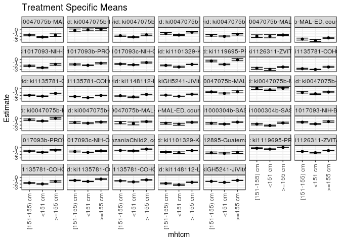

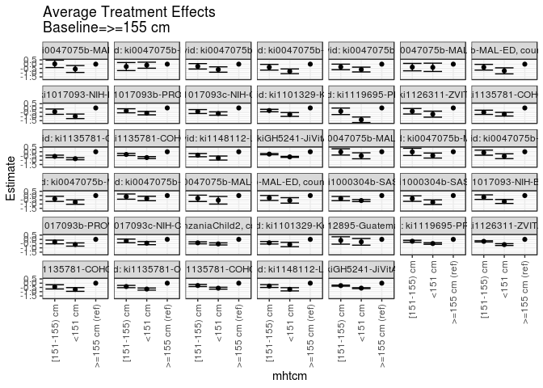

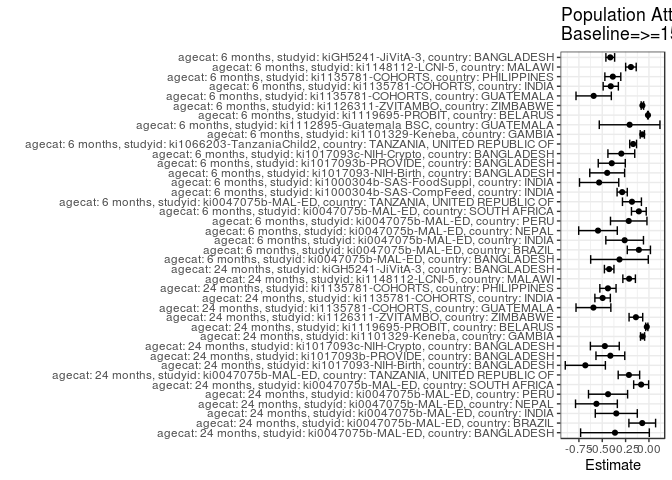

## Results Table

### Parameter: TSM

| agecat | studyid | country | intervention_level | baseline_level | estimate | ci_lower | ci_upper |
| --- | --- | --- | --- | --- | --- | --- | --- |
| 6 months | ki0047075b-MAL-ED | BANGLADESH | >=155 cm | NA | -0.8901504 | -1.2075618 | -0.5727391 |
| 6 months | ki0047075b-MAL-ED | BANGLADESH | <151 cm | NA | -1.3647587 | -1.5187535 | -1.2107639 |
| 6 months | ki0047075b-MAL-ED | BANGLADESH | [151-155) cm | NA | -0.9108806 | -1.1007568 | -0.7210044 |
| 6 months | ki0047075b-MAL-ED | BRAZIL | >=155 cm | NA | 0.1589362 | -0.0320200 | 0.3498924 |
| 6 months | ki0047075b-MAL-ED | BRAZIL | <151 cm | NA | -0.2873353 | -0.5129279 | -0.0617427 |
| 6 months | ki0047075b-MAL-ED | BRAZIL | [151-155) cm | NA | 0.1433482 | -0.2386082 | 0.5253045 |
| 6 months | ki0047075b-MAL-ED | INDIA | >=155 cm | NA | -0.9546743 | -1.1750990 | -0.7342497 |
| 6 months | ki0047075b-MAL-ED | INDIA | <151 cm | NA | -1.4789084 | -1.6574359 | -1.3003810 |
| 6 months | ki0047075b-MAL-ED | INDIA | [151-155) cm | NA | -1.0594496 | -1.2606866 | -0.8582126 |
| 6 months | ki0047075b-MAL-ED | NEPAL | >=155 cm | NA | -0.0154065 | -0.2282923 | 0.1974794 |
| 6 months | ki0047075b-MAL-ED | NEPAL | <151 cm | NA | -0.7808879 | -0.9290000 | -0.6327758 |
| 6 months | ki0047075b-MAL-ED | NEPAL | [151-155) cm | NA | -0.4019966 | -0.6156723 | -0.1883208 |
| 6 months | ki0047075b-MAL-ED | PERU | >=155 cm | NA | -1.1107089 | -1.3232950 | -0.8981228 |
| 6 months | ki0047075b-MAL-ED | PERU | <151 cm | NA | -1.4544225 | -1.6050796 | -1.3037653 |
| 6 months | ki0047075b-MAL-ED | PERU | [151-155) cm | NA | -1.2316495 | -1.4516039 | -1.0116951 |
| 6 months | ki0047075b-MAL-ED | SOUTH AFRICA | >=155 cm | NA | -0.9646657 | -1.1102515 | -0.8190800 |
| 6 months | ki0047075b-MAL-ED | SOUTH AFRICA | <151 cm | NA | -1.5174626 | -1.9432766 | -1.0916486 |
| 6 months | ki0047075b-MAL-ED | SOUTH AFRICA | [151-155) cm | NA | -1.2895344 | -1.6330471 | -0.9460217 |
| 6 months | ki0047075b-MAL-ED | TANZANIA, UNITED REPUBLIC OF | >=155 cm | NA | -1.1781232 | -1.3260194 | -1.0302269 |
| 6 months | ki0047075b-MAL-ED | TANZANIA, UNITED REPUBLIC OF | <151 cm | NA | -1.7484590 | -2.0401971 | -1.4567209 |
| 6 months | ki0047075b-MAL-ED | TANZANIA, UNITED REPUBLIC OF | [151-155) cm | NA | -1.4597122 | -1.7120650 | -1.2073594 |
| 6 months | ki1000304b-SAS-CompFeed | INDIA | >=155 cm | NA | -1.1202462 | -1.2081917 | -1.0323007 |
| 6 months | ki1000304b-SAS-CompFeed | INDIA | <151 cm | NA | -1.7067530 | -1.8465093 | -1.5669966 |
| 6 months | ki1000304b-SAS-CompFeed | INDIA | [151-155) cm | NA | -1.4721145 | -1.6824905 | -1.2617385 |
| 6 months | ki1000304b-SAS-FoodSuppl | INDIA | >=155 cm | NA | -1.3546531 | -1.5802447 | -1.1290615 |
| 6 months | ki1000304b-SAS-FoodSuppl | INDIA | <151 cm | NA | -2.1322183 | -2.2760688 | -1.9883678 |
| 6 months | ki1000304b-SAS-FoodSuppl | INDIA | [151-155) cm | NA | -1.7145382 | -1.9464176 | -1.4826588 |
| 6 months | ki1017093-NIH-Birth | BANGLADESH | >=155 cm | NA | -0.9602035 | -1.1651998 | -0.7552071 |
| 6 months | ki1017093-NIH-Birth | BANGLADESH | <151 cm | NA | -1.6564513 | -1.7665837 | -1.5463188 |
| 6 months | ki1017093-NIH-Birth | BANGLADESH | [151-155) cm | NA | -1.1432313 | -1.3174294 | -0.9690333 |

[output cut: 90 more lines]

### Parameter: E(Y)

| agecat | studyid | country | intervention_level | baseline_level | estimate | ci_lower | ci_upper |
| --- | --- | --- | --- | --- | --- | --- | --- |
| 6 months | ki0047075b-MAL-ED | BANGLADESH | NA | NA | -1.2056777 | -1.3231497 | -1.0882058 |
| 6 months | ki0047075b-MAL-ED | BRAZIL | NA | NA | 0.0510207 | -0.0930194 | 0.1950608 |
| 6 months | ki0047075b-MAL-ED | INDIA | NA | NA | -1.2148369 | -1.3332371 | -1.0964367 |
| 6 months | ki0047075b-MAL-ED | NEPAL | NA | NA | -0.5610593 | -0.6737915 | -0.4483272 |
| 6 months | ki0047075b-MAL-ED | PERU | NA | NA | -1.3272488 | -1.4359649 | -1.2185326 |
| 6 months | ki0047075b-MAL-ED | SOUTH AFRICA | NA | NA | -1.0728012 | -1.2026830 | -0.9429194 |
| 6 months | ki0047075b-MAL-ED | TANZANIA, UNITED REPUBLIC OF | NA | NA | -1.3601215 | -1.4821830 | -1.2380600 |
| 6 months | ki1000304b-SAS-CompFeed | INDIA | NA | NA | -1.4068893 | -1.4981242 | -1.3156543 |
| 6 months | ki1000304b-SAS-FoodSuppl | INDIA | NA | NA | -1.8882058 | -1.9998264 | -1.7765852 |
| 6 months | ki1017093-NIH-Birth | BANGLADESH | NA | NA | -1.4073821 | -1.4960598 | -1.3187043 |
| 6 months | ki1017093b-PROVIDE | BANGLADESH | NA | NA | -1.0848568 | -1.1613109 | -1.0084028 |
| 6 months | ki1017093c-NIH-Crypto | BANGLADESH | NA | NA | -1.1986783 | -1.2700937 | -1.1272630 |
| 6 months | ki1066203-TanzaniaChild2 | TANZANIA, UNITED REPUBLIC OF | NA | NA | -0.5424553 | -0.5916933 | -0.4932174 |
| 6 months | ki1101329-Keneba | GAMBIA | NA | NA | -0.9159303 | -0.9650776 | -0.8667830 |
| 6 months | ki1112895-Guatemala BSC | GUATEMALA | NA | NA | -1.5599206 | -1.6885363 | -1.4313049 |
| 6 months | ki1119695-PROBIT | BELARUS | NA | NA | 0.1157811 | 0.0226850 | 0.2088772 |
| 6 months | ki1126311-ZVITAMBO | ZIMBABWE | NA | NA | -0.9009844 | -0.9286528 | -0.8733161 |
| 6 months | ki1135781-COHORTS | GUATEMALA | NA | NA | -1.8116225 | -1.8800533 | -1.7431916 |
| 6 months | ki1135781-COHORTS | INDIA | NA | NA | -0.9254151 | -0.9779952 | -0.8728349 |
| 6 months | ki1135781-COHORTS | PHILIPPINES | NA | NA | -1.1405724 | -1.1824954 | -1.0986493 |
| 6 months | ki1148112-LCNI-5 | MALAWI | NA | NA | -1.6577751 | -1.7275296 | -1.5880207 |
| 6 months | kiGH5241-JiVitA-3 | BANGLADESH | NA | NA | -1.3139055 | -1.3370256 | -1.2907854 |
| 24 months | ki0047075b-MAL-ED | BANGLADESH | NA | NA | -1.9431132 | -2.0691678 | -1.8170586 |
| 24 months | ki0047075b-MAL-ED | BRAZIL | NA | NA | 0.0418343 | -0.1253834 | 0.2090521 |
| 24 months | ki0047075b-MAL-ED | INDIA | NA | NA | -1.8439159 | -1.9704751 | -1.7173568 |
| 24 months | ki0047075b-MAL-ED | NEPAL | NA | NA | -1.2752193 | -1.3954783 | -1.1549603 |
| 24 months | ki0047075b-MAL-ED | PERU | NA | NA | -1.7500995 | -1.8705474 | -1.6296516 |
| 24 months | ki0047075b-MAL-ED | SOUTH AFRICA | NA | NA | -1.6220299 | -1.7590593 | -1.4850005 |
| 24 months | ki0047075b-MAL-ED | TANZANIA, UNITED REPUBLIC OF | NA | NA | -2.6058879 | -2.7403043 | -2.4714714 |
| 24 months | ki1017093-NIH-Birth | BANGLADESH | NA | NA | -2.1807945 | -2.2835902 | -2.0779987 |
| 24 months | ki1017093b-PROVIDE | BANGLADESH | NA | NA | -1.5839236 | -1.6672059 | -1.5006413 |
| 24 months | ki1017093c-NIH-Crypto | BANGLADESH | NA | NA | -1.4295331 | -1.5127726 | -1.3462935 |
| 24 months | ki1101329-Keneba | GAMBIA | NA | NA | -1.5677937 | -1.6196515 | -1.5159358 |
| 24 months | ki1119695-PROBIT | BELARUS | NA | NA | -0.1322181 | -0.4300523 | 0.1656161 |
| 24 months | ki1126311-ZVITAMBO | ZIMBABWE | NA | NA | -2.4107937 | -2.5337436 | -2.2878437 |
| 24 months | ki1135781-COHORTS | GUATEMALA | NA | NA | -2.8678134 | -2.9347113 | -2.8009156 |
| 24 months | ki1135781-COHORTS | INDIA | NA | NA | -1.8566355 | -1.9110340 | -1.8022370 |
| 24 months | ki1135781-COHORTS | PHILIPPINES | NA | NA | -2.3898650 | -2.4346888 | -2.3450412 |
| 24 months | ki1148112-LCNI-5 | MALAWI | NA | NA | -1.8744367 | -1.9556750 | -1.7931984 |
| 24 months | kiGH5241-JiVitA-3 | BANGLADESH | NA | NA | -2.0127573 | -2.0405350 | -1.9849796 |

### Parameter: ATE

| agecat | studyid | country | intervention_level | baseline_level | estimate | ci_lower | ci_upper |
| --- | --- | --- | --- | --- | --- | --- | --- |
| 6 months | ki0047075b-MAL-ED | BANGLADESH | >=155 cm | >=155 cm | 0.0000000 | 0.0000000 | 0.0000000 |
| 6 months | ki0047075b-MAL-ED | BANGLADESH | <151 cm | >=155 cm | -0.4746083 | -0.8275061 | -0.1217105 |
| 6 months | ki0047075b-MAL-ED | BANGLADESH | [151-155) cm | >=155 cm | -0.0207302 | -0.3906768 | 0.3492165 |
| 6 months | ki0047075b-MAL-ED | BRAZIL | >=155 cm | >=155 cm | 0.0000000 | 0.0000000 | 0.0000000 |
| 6 months | ki0047075b-MAL-ED | BRAZIL | <151 cm | >=155 cm | -0.4462715 | -0.7418147 | -0.1507284 |
| 6 months | ki0047075b-MAL-ED | BRAZIL | [151-155) cm | >=155 cm | -0.0155880 | -0.4413169 | 0.4101408 |
| 6 months | ki0047075b-MAL-ED | INDIA | >=155 cm | >=155 cm | 0.0000000 | 0.0000000 | 0.0000000 |
| 6 months | ki0047075b-MAL-ED | INDIA | <151 cm | >=155 cm | -0.5242341 | -0.8077882 | -0.2406800 |
| 6 months | ki0047075b-MAL-ED | INDIA | [151-155) cm | >=155 cm | -0.1047752 | -0.4041424 | 0.1945920 |
| 6 months | ki0047075b-MAL-ED | NEPAL | >=155 cm | >=155 cm | 0.0000000 | 0.0000000 | 0.0000000 |
| 6 months | ki0047075b-MAL-ED | NEPAL | <151 cm | >=155 cm | -0.7654815 | -1.0247996 | -0.5061634 |
| 6 months | ki0047075b-MAL-ED | NEPAL | [151-155) cm | >=155 cm | -0.3865901 | -0.6878311 | -0.0853491 |
| 6 months | ki0047075b-MAL-ED | PERU | >=155 cm | >=155 cm | 0.0000000 | 0.0000000 | 0.0000000 |
| 6 months | ki0047075b-MAL-ED | PERU | <151 cm | >=155 cm | -0.3437136 | -0.6047328 | -0.0826943 |
| 6 months | ki0047075b-MAL-ED | PERU | [151-155) cm | >=155 cm | -0.1209406 | -0.4267928 | 0.1849116 |
| 6 months | ki0047075b-MAL-ED | SOUTH AFRICA | >=155 cm | >=155 cm | 0.0000000 | 0.0000000 | 0.0000000 |
| 6 months | ki0047075b-MAL-ED | SOUTH AFRICA | <151 cm | >=155 cm | -0.5527969 | -1.0029017 | -0.1026920 |
| 6 months | ki0047075b-MAL-ED | SOUTH AFRICA | [151-155) cm | >=155 cm | -0.3248686 | -0.6980695 | 0.0483322 |
| 6 months | ki0047075b-MAL-ED | TANZANIA, UNITED REPUBLIC OF | >=155 cm | >=155 cm | 0.0000000 | 0.0000000 | 0.0000000 |
| 6 months | ki0047075b-MAL-ED | TANZANIA, UNITED REPUBLIC OF | <151 cm | >=155 cm | -0.5703358 | -0.8943435 | -0.2463281 |
| 6 months | ki0047075b-MAL-ED | TANZANIA, UNITED REPUBLIC OF | [151-155) cm | >=155 cm | -0.2815890 | -0.5737208 | 0.0105427 |
| 6 months | ki1000304b-SAS-CompFeed | INDIA | >=155 cm | >=155 cm | 0.0000000 | 0.0000000 | 0.0000000 |
| 6 months | ki1000304b-SAS-CompFeed | INDIA | <151 cm | >=155 cm | -0.5865067 | -0.7048054 | -0.4682080 |
| 6 months | ki1000304b-SAS-CompFeed | INDIA | [151-155) cm | >=155 cm | -0.3518683 | -0.6006771 | -0.1030594 |
| 6 months | ki1000304b-SAS-FoodSuppl | INDIA | >=155 cm | >=155 cm | 0.0000000 | 0.0000000 | 0.0000000 |
| 6 months | ki1000304b-SAS-FoodSuppl | INDIA | <151 cm | >=155 cm | -0.7775651 | -1.0456240 | -0.5095062 |
| 6 months | ki1000304b-SAS-FoodSuppl | INDIA | [151-155) cm | >=155 cm | -0.3598851 | -0.6835713 | -0.0361989 |
| 6 months | ki1017093-NIH-Birth | BANGLADESH | >=155 cm | >=155 cm | 0.0000000 | 0.0000000 | 0.0000000 |
| 6 months | ki1017093-NIH-Birth | BANGLADESH | <151 cm | >=155 cm | -0.6962478 | -0.9288469 | -0.4636487 |
| 6 months | ki1017093-NIH-Birth | BANGLADESH | [151-155) cm | >=155 cm | -0.1830279 | -0.4512923 | 0.0852366 |

[output cut: 90 more lines]

### Parameter: PAR

| agecat | studyid | country | intervention_level | baseline_level | estimate | ci_lower | ci_upper |
| --- | --- | --- | --- | --- | --- | --- | --- |
| 6 months | ki0047075b-MAL-ED | BANGLADESH | >=155 cm | NA | -0.3155273 | -0.6241409 | -0.0069137 |
| 6 months | ki0047075b-MAL-ED | BRAZIL | >=155 cm | NA | -0.1079155 | -0.2319320 | 0.0161011 |
| 6 months | ki0047075b-MAL-ED | INDIA | >=155 cm | NA | -0.2601625 | -0.4617317 | -0.0585934 |
| 6 months | ki0047075b-MAL-ED | NEPAL | >=155 cm | NA | -0.5456529 | -0.7522976 | -0.3390081 |
| 6 months | ki0047075b-MAL-ED | PERU | >=155 cm | NA | -0.2165399 | -0.4117961 | -0.0212837 |
| 6 months | ki0047075b-MAL-ED | SOUTH AFRICA | >=155 cm | NA | -0.1081355 | -0.1872149 | -0.0290560 |
| 6 months | ki0047075b-MAL-ED | TANZANIA, UNITED REPUBLIC OF | >=155 cm | NA | -0.1819983 | -0.2834796 | -0.0805169 |
| 6 months | ki1000304b-SAS-CompFeed | INDIA | >=155 cm | NA | -0.2866430 | -0.3412098 | -0.2320762 |
| 6 months | ki1000304b-SAS-FoodSuppl | INDIA | >=155 cm | NA | -0.5335527 | -0.7437262 | -0.3233792 |
| 6 months | ki1017093-NIH-Birth | BANGLADESH | >=155 cm | NA | -0.4471786 | -0.6339359 | -0.2604212 |
| 6 months | ki1017093b-PROVIDE | BANGLADESH | >=155 cm | NA | -0.3981738 | -0.5429586 | -0.2533890 |
| 6 months | ki1017093c-NIH-Crypto | BANGLADESH | >=155 cm | NA | -0.2958262 | -0.4394218 | -0.1522305 |
| 6 months | ki1066203-TanzaniaChild2 | TANZANIA, UNITED REPUBLIC OF | >=155 cm | NA | -0.1691421 | -0.2057090 | -0.1325751 |
| 6 months | ki1101329-Keneba | GAMBIA | >=155 cm | NA | -0.0709516 | -0.0935828 | -0.0483204 |
| 6 months | ki1112895-Guatemala BSC | GUATEMALA | >=155 cm | NA | -0.2069581 | -0.5319530 | 0.1180367 |
| 6 months | ki1119695-PROBIT | BELARUS | >=155 cm | NA | -0.0102852 | -0.0141741 | -0.0063962 |
| 6 months | ki1126311-ZVITAMBO | ZIMBABWE | >=155 cm | NA | -0.0701141 | -0.0832834 | -0.0569447 |
| 6 months | ki1135781-COHORTS | GUATEMALA | >=155 cm | NA | -0.5920235 | -0.7811503 | -0.4028966 |
| 6 months | ki1135781-COHORTS | INDIA | >=155 cm | NA | -0.4090104 | -0.4904136 | -0.3276073 |
| 6 months | ki1135781-COHORTS | PHILIPPINES | >=155 cm | NA | -0.3868580 | -0.4720690 | -0.3016470 |
| 6 months | ki1148112-LCNI-5 | MALAWI | >=155 cm | NA | -0.1929186 | -0.2495141 | -0.1363230 |
| 6 months | kiGH5241-JiVitA-3 | BANGLADESH | >=155 cm | NA | -0.4141869 | -0.4610287 | -0.3673452 |
| 24 months | ki0047075b-MAL-ED | BANGLADESH | >=155 cm | NA | -0.3638694 | -0.7318237 | 0.0040849 |
| 24 months | ki0047075b-MAL-ED | BRAZIL | >=155 cm | NA | -0.0716017 | -0.2145830 | 0.0713796 |
| 24 months | ki0047075b-MAL-ED | INDIA | >=155 cm | NA | -0.3496888 | -0.5747434 | -0.1246341 |
| 24 months | ki0047075b-MAL-ED | NEPAL | >=155 cm | NA | -0.5623919 | -0.7862758 | -0.3385080 |
| 24 months | ki0047075b-MAL-ED | PERU | >=155 cm | NA | -0.4379370 | -0.6473062 | -0.2285677 |
| 24 months | ki0047075b-MAL-ED | SOUTH AFRICA | >=155 cm | NA | -0.0833768 | -0.1635604 | -0.0031932 |
| 24 months | ki0047075b-MAL-ED | TANZANIA, UNITED REPUBLIC OF | >=155 cm | NA | -0.2144218 | -0.3293348 | -0.0995088 |
| 24 months | ki1017093-NIH-Birth | BANGLADESH | >=155 cm | NA | -0.6813136 | -0.8961620 | -0.4664652 |
| 24 months | ki1017093b-PROVIDE | BANGLADESH | >=155 cm | NA | -0.4131020 | -0.5673540 | -0.2588500 |
| 24 months | ki1017093c-NIH-Crypto | BANGLADESH | >=155 cm | NA | -0.4724384 | -0.6270741 | -0.3178028 |
| 24 months | ki1101329-Keneba | GAMBIA | >=155 cm | NA | -0.0682912 | -0.0902143 | -0.0463680 |
| 24 months | ki1119695-PROBIT | BELARUS | >=155 cm | NA | -0.0230832 | -0.0349089 | -0.0112575 |
| 24 months | ki1126311-ZVITAMBO | ZIMBABWE | >=155 cm | NA | -0.1397172 | -0.2128082 | -0.0666262 |
| 24 months | ki1135781-COHORTS | GUATEMALA | >=155 cm | NA | -0.5945495 | -0.7811038 | -0.4079952 |
| 24 months | ki1135781-COHORTS | INDIA | >=155 cm | NA | -0.4961096 | -0.5790226 | -0.4131966 |
| 24 months | ki1135781-COHORTS | PHILIPPINES | >=155 cm | NA | -0.4390472 | -0.5258867 | -0.3522077 |
| 24 months | ki1148112-LCNI-5 | MALAWI | >=155 cm | NA | -0.2121728 | -0.2794356 | -0.1449100 |
| 24 months | kiGH5241-JiVitA-3 | BANGLADESH | >=155 cm | NA | -0.4259160 | -0.4769043 | -0.3749276 |